# Тема 2. Численное решение систем линейных уравнений. Повторение.

Решение систем линейных уравнений пришло к нам как математический инструмент из задач экономики, биологии, физики и др..
В простейшем случае это может быть система линейных уравнений из 2 переменных. $$\begin{cases} a_{11}x+a_{12}y=b_1\\ a_{21}x+a_{22}y=b_2 \end{cases}$$ Где $a_{11}, a_{12}, a_{21}, a_{22}$ - числовые коэффициенты, $b_1, b_2$ - числовые коэффициенты, называемые свободными членами. $x, y $ - неизвестных, или переменные. Подобные системы уравнения в школьном курсе решаются весьма тривеальным способом... Для решения подобных систем линейных уравнений в школе обычно практикуются два способа: графический и аналитический.

- Рассмотрим пример первый. Ответ только один. $$\begin{cases} x+2y=3\\ 4x+5y=9 \end{cases}$$ Графический способ заключается в построении графиков и определении точек пересечения их...

```julia
#Если не работает, то у слудующих 2 строк сними комментарии (убери решетки),
#запуст и накати недостающий пакет
#using Pkg
#Pkg.add("Plots")
using Plots
plot(size = (250,150))#Указали реальные размеры графика
plot!(xlims = (0.5,2))#Указали диапазон по оси OX, только для отображения оси
plot!(ylims = (0.5,1.5))#Указали диапазон по оси OY, только для отображения оси
plot!((x)->((3-x)/2), label="x+2y=3")
plot!((x)->((9-4*x)/5), label="4x+5y=9")
```

[figure not shown]

По результатам графического способа решения ответ: (1,1)  
Минус такого подхода в человеческом факторе. Требуется некоторая аккуратность чтобы нарисовать график и с высокой точностью на глаз определенить точку пересечения.  
По этой причине предпочтительней второй способ. Аналитический:

1) $\begin{cases}x+2y=3\\4x+5y=9\end{cases}$ 2) $\begin{cases}x=3-2y\\4x+5y=9\end{cases}$ 3)$\begin{cases}x=3-2y\\4(3-2y)+5y=9\end{cases}$  
4)$\begin{cases}x=3-2y\\12-8y+5y=9\end{cases}$ 5)$\begin{cases}x=3-2y\\12-3y=9\end{cases}$ 6)$\begin{cases}x=3-2y\\12-9=3y\end{cases}$  
7)$\begin{cases}x=3-2y\\3=3y\end{cases}$ 8)$\begin{cases}x=3-2y\\y=1\end{cases}$ 9)$\begin{cases}x=3-2\\y=1\end{cases}$  
10)$\begin{cases}x=1\\y=1\end{cases}$

- Рассмотрим пример второй. Ответов безконечно много. $$\begin{cases}x+2y=3\\3x+6y=9\end{cases}$$ Здесь приведен пример когда в системе линейных уравнений приведены одинаковые уравнений.
  Продемонстрировать можно путем построения этих двух наложенных друг на друга прямых (графиков линейных функций)

```julia
using Plots
plot(size = (250,150))#Указали реальные размеры графика
plot!(xlims = (0.5,2))#Указали диапазон по оси OX, только для отображения оси
plot!(ylims = (0.5,1.5))#Указали диапазон по оси OY, только для отображения оси
plot!((x)->((3-x)/2), label="x+2y=3")
plot!((x)->((9-3*x)/6), label="3x+6y=9")
```

[figure not shown]

То же самое можно подтвердить аналитическим путем:

1) $\begin{cases}x+2y=3\\3x+6y=9\end{cases}$ 2) $\begin{cases}x=3-2y\\3x+6y=9\end{cases}$ 3) $\begin{cases}x=3-2y\\3(3-2y)+6y=9\end{cases}$ 4) $\begin{cases}x=3-2y\\9-6y+6y-9=0\end{cases}$  
Какие бы мы манипуляции не получали , в итоге мы получим истеное высказывание. Это означает что ответов безконечно много..

- Рассмотрим пример третий. Ответов нет. $$\begin{cases}x+2y=3\\3x+6y=10\end{cases}$$ 1) $\begin{cases}x=3-2y\\3x+6y=10\end{cases}$ 2) $\begin{cases}x=3-2y\\3(3-2y)+6y=10\end{cases}$ 3) $\begin{cases}x=3-2y\\9-6y+6y=10\end{cases}$ 4) $\begin{cases}x=3-2y\\9=10\end{cases}$ Какие бы мы манипуляции не производили, результатом алгеброических преобразований будет ложное высказывание.

```julia
using Plots
plot(size = (250,150))#Указали реальные размеры графика
plot!(xlims = (0.5,2))#Указали диапазон по оси OX, только для отображения оси
plot!(ylims = (0.5,1.5))#Указали диапазон по оси OY, только для отображения оси
plot!((x)->((3-x)/2), label="x+2y=3")
plot!((x)->((10-3*x)/6), label="3x+6y=10")
```

[figure not shown]

Графики функций подтверждают, что мы получили 2 паралельные прямые. То есть они не пересекаются и решений системы линейных уравнений нет.

### Определение.

> Система линейных уравнений называется:
> - совместной, если она имеет решения (одно или бесконечно много);
> - несовместной, если она не имеет решений,
> - определенной, если она имеет единственное решение;
> - неопределенной, если она имеет бесконечно много решений

На этом мы в кратце повторили школьный материал

# Тема 2. Численное решение систем линейных уравнений.

Решение систем линейных уравнений пришло к нам как математический инструмент из задач экономики, биологии, физики и др..

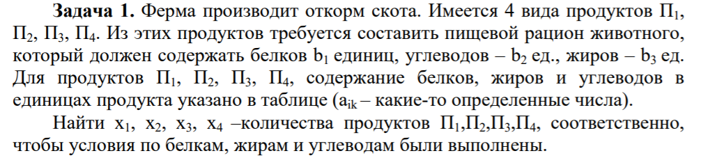

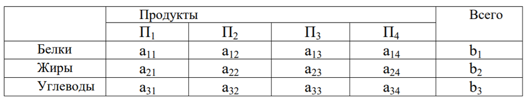

Запишем систему линейных уравнений **в общем виде**: $$\begin{cases} a_{11}x_1+a_{12}x_2+\ldots+a_{1n}x_b=b_1 \\a_{21}x_1+a_{22}x_2+\ldots+a_{2n}x_b=b_2 \\\ldots \\a_{m1}x_1+a_{m2}x_2+\ldots+a_{mn}x_b=b_m \end{cases}$$ В этой системе из m линейных уравнений $x_1, x_2, \ldots, x_n$ - n неизвестных; $a_{ij}$ - числовые коэффициенты, где $i=1, \ldots,m; j=1, \ldots,n; b_i$ - некоторые числа, называемые свободными членами.

> **Матрицей системы линейных уравнений** будем называть матрицу $А$  
> **Расширенной матрицей системы линейных уравнений** будем называть матрицу $(A|B)$

$A=\begin{pmatrix} \alpha_{11}& \alpha_{12}& \ldots&\alpha_{1n}\\ \alpha_{21}& \alpha_{22}& \ldots&\alpha_{2n}\\ \ldots&\ldots&\ldots&\ldots\\ \alpha_{m1}& \alpha_{m2}& \ldots&\alpha_{mn}\\ \end{pmatrix};$ $(A|B)=\begin{pmatrix} \alpha_{11}& \alpha_{12}& \ldots&\alpha_{1n}&|&\beta_1\\ \alpha_{21}& \alpha_{22}& \ldots&\alpha_{2n}&|&\beta_2\\ \ldots&\ldots&\ldots&\ldots&|&\ldots\\ \alpha_{m1}& \alpha_{m2}& \ldots&\alpha_{mn}&|&\beta_n\\ \end{pmatrix};$

> **Решением** системы линейных называют кортеж(набор) значений.$\overline{X}=(x_1,x_2,\ldots,x_n)$ что при подстановке в систему уравнений каждое уравнение превращается в верное высказывание

При этом запись в виде системы линейных уравнение эквивалентно записи в виде расширенной матрици.

# Метод Гауса

Решение системы уравнения не изменится если:

- уравнения поменять местами;
- умножить уравнения на число, отличное от 0;
- к одному из уравнений прибавить другое; Для расширенной матрици справедливо, что решение системы не изменится если:
- произвести перестановку строк;
- умножить строки на число, отличное от 0;
- прибавить к одной строке другую строку; Рассмотрим аналитическое решение системы линейных уравнений методом Гауса на следующем примере:

$$\begin{cases} x+2y+3z=4 \\2x+5y+7z=3 \\3x+y-z=1 \end{cases}$$

### Прямой ход метода Гаусса.

Шаг первый. Выбор ведущей строки.  
Есть несколько способов выбора ведущей строки.

- Первый способ. Выбор в качестве ведущей строки, строки в которой наибольший модуль параметра при первой неизвестной.
- Второй способ. Выбор в качестве ведущей строки, строки в которой найменьший модуль параметра при первой неизвестной.
- Третий способ. Разделить каждую часть каждого уравнения на коэффициент при первой неизвестной. Пулучатся первые коэффициенты равные 1.

В общем выбирается именно тот способ и та строка системы лин. ур., работа с которой будет наиболее удобна.

Итак, Метод Гауса относится к точным методам. Если в промежуточных вычислениях не производились округления чисел, то полученый результат точный. На практике обладать точным значением велечины нам никогда не суждено. По этому операии производятся над приближенными значениями коэффициентов. Соответственно, погрешность метода Гауса - это погрешность округления, ну и всех математических операций что были применены.  
За сим, вводят понятие **невязки**. За истинное знаечние числа принимается свободный коэффициент.За приближенное значение чиста - остальная часть уравнения. Так приходим к следующей формуле...

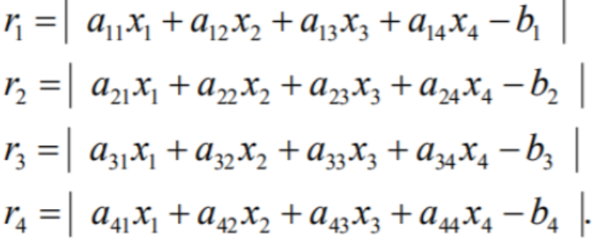

Точность найденого решения можно оценить набором невязок. Если невязки малы то решение подобрано точно.  
Приведем пример

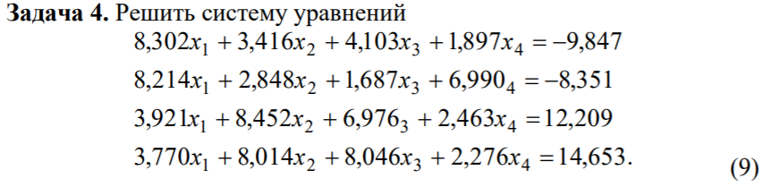

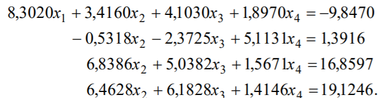

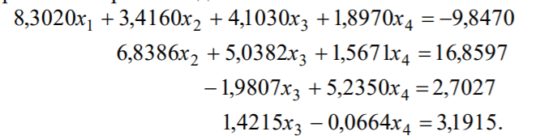

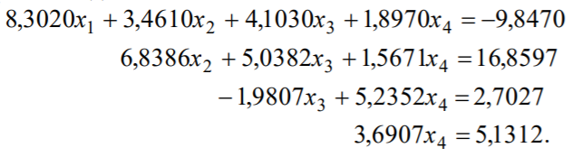

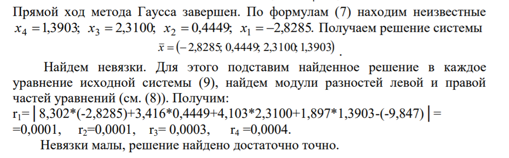

Остается вопрос, откуда взялись такие невязки. Напомним, что нами осществлялись арифметические операции с приближенными числами, и погрешность результата вычислений со временем только растет...

Итак мы подобрались к первому, рассматриваемому нами, итеративному алгоритму из курса численных методов.

[figure not shown]